# Mediterranean fishing seen from space

A first look at AIS fishing effort and SAR vessel detections, 2017-2024. Pre-workshop analyses for the Global Fishing Watch Mediterranean Data Lab

Théophile L. Mouton

2026-10-15

**Load the gfwr extracts, clip to the FAO Mediterranean**

```r
# Produced by R/01_download_gfw.R (gfwr::gfw_ais_fishing_hours and
# gfwr::gfw_sar_vessel_detections, 0.1 degree, monthly, 2017-2024).
# GFW Lat/Lon are the lower-left corner of each 0.1 degree cell and carry
# floating-point noise, so they are rounded to 1 decimal to get stable cell keys.
ais <- readRDS("data/processed/ais_med_monthly.rds") |>
  mutate(lon = round(lon, 1), lat = round(lat, 1))
sar <- readRDS("data/processed/sar_med_monthly.rds") |>
  mutate(lon = round(lon, 1), lat = round(lat, 1))
ov  <- readRDS(params$overpasses) |>
  mutate(lon = round(lon, 1), lat = round(lat, 1))

# Official FAO Mediterranean: Major Fishing Area 37, subareas 37.1-37.3
# (Black Sea 37.4 excluded). Cells are kept if their square touches it, and
# assigned to the FAO division containing (or nearest to) the cell centre.
fao <- st_read("data_ref/fao_area37_med.geojson", quiet = TRUE)
med <- fao |> filter(F_LEVEL == "SUBAREA") |> st_union() |> st_make_valid()
div <- fao |> filter(F_LEVEL == "DIVISION") |>
  mutate(division = recode(F_CODE,
    "37.1.1" = "Balearic", "37.1.2" = "Gulf of Lions", "37.1.3" = "Sardinia",
    "37.2.1" = "Adriatic", "37.2.2" = "Ionian",
    "37.3.1" = "Aegean",   "37.3.2" = "Levant"))

cells <- distinct(bind_rows(select(ais, lon, lat), select(sar, lon, lat)))
sq <- st_sfc(lapply(seq_len(nrow(cells)), \(i) {
  x <- cells$lon[i]; y <- cells$lat[i]
  st_polygon(list(rbind(c(x, y), c(x + .1, y), c(x + .1, y + .1), c(x, y + .1), c(x, y))))
}), crs = 4326)
cells$in_med <- lengths(st_intersects(sq, med)) > 0
ctr <- suppressWarnings(st_centroid(sq))
cells$division <- div$division[st_nearest_feature(ctr, div)]
cells <- filter(cells, in_med) |> select(-in_med)

ais <- inner_join(ais, cells, by = c("lon", "lat"))
sar <- inner_join(sar, cells, by = c("lon", "lat"))

yrs <- sort(intersect(unique(ais$year), unique(sar$year)))
ais <- filter(ais, year %in% yrs)
sar <- filter(sar, year %in% yrs)
n_years <- length(yrs)

ais <- ais |>
  mutate(gear = case_when(
    geartype == "trawlers"          ~ "Trawlers",
    grepl("longline", geartype)     ~ "Longlines",
    grepl("purse_seine", geartype)  ~ "Purse seines",
    TRUE                            ~ "Other / unknown"),
    gear = factor(gear, c("Trawlers", "Purse seines", "Longlines", "Other / unknown")))

land <- rnaturalearth::ne_countries(scale = "medium", returnclass = "sf") |>
  st_make_valid() |>
  st_crop(c(xmin = -6.5, xmax = 37, ymin = 29.5, ymax = 46.5))

map_base <- list(
  geom_sf(data = land, fill = "grey90", colour = "grey75", linewidth = 0.15, inherit.aes = FALSE),
  geom_sf(data = med, fill = NA, colour = "grey45", linewidth = 0.2, inherit.aes = FALSE),
  coord_sf(xlim = c(-6, 36.5), ylim = c(30, 46), expand = FALSE),
  theme_ocean(10),
  theme(axis.title = element_blank(), legend.key.width = unit(14, "mm"),
        legend.key.height = unit(3, "mm"))
)
# geom_tile is centred on x/y: plot at the cell centre
tile <- function(...) geom_tile(aes(lon + 0.05, lat + 0.05, ...), width = 0.1, height = 0.1)
```

**Normalise SAR detections by Sentinel-1 overpasses**

```r
# Overpasses: distinct Sentinel-1 IW passes covering each cell centre per month
# (R/03_s1_overpasses.R, Copernicus Data Space catalogue).
# Detections per overpass = mean number of vessels the radar sees in a cell
# each time it looks. Summed over cells it is a basin-wide 'snapshot' count:
# the number of vessels a single complete radar look would detect.
sar_cm <- sar |>
  group_by(lon, lat, division, year, month) |>
  summarise(det_matched   = sum(detections[matched]),
            det_unmatched = sum(detections[!matched]), .groups = "drop") |>
  left_join(ov, by = c("lon", "lat", "year", "month"))

no_cover <- sar_cm |> filter(is.na(overpasses) | overpasses == 0)
sar_cm <- sar_cm |> filter(overpasses > 0)

snap_month <- sar_cm |>
  group_by(year, month) |>
  summarise(matched   = sum(det_matched / overpasses),
            unmatched = sum(det_unmatched / overpasses), .groups = "drop") |>
  mutate(date = as.Date(sprintf("%d-%02d-01", year, month)))

ov_month <- ov |>
  inner_join(cells, by = c("lon", "lat")) |>
  group_by(year, month) |>
  summarise(median_ov = median(overpasses), .groups = "drop") |>
  mutate(date = as.Date(sprintf("%d-%02d-01", year, month)))
```

**Annual and cell-level summaries**

```r
summary_year <- ais |>
  group_by(year) |>
  summarise(ais_hours   = sum(fishing_hours),
            trawl_share = sum(fishing_hours[gear == "Trawlers"]) / sum(fishing_hours),
            cells       = n_distinct(lon, lat)) |>
  left_join(sar |> group_by(year) |>
              summarise(sar_det = sum(detections),
                        dark_share = sum(detections[!matched]) / sum(detections)),
            by = "year") |>
  left_join(ov |> inner_join(cells, by = c("lon", "lat")) |>
              group_by(year) |> summarise(ov_year = median(overpasses) * 12),
            by = "year") |>
  left_join(snap_month |> group_by(year) |>
              summarise(snap = mean(matched + unmatched),
                        snap_dark = mean(unmatched) / mean(matched + unmatched)),
            by = "year")

ais_cell <- ais |>
  group_by(lon, lat) |>
  summarise(hours = sum(fishing_hours) / n_years, .groups = "drop")

sar_cell <- sar_cm |>
  group_by(lon, lat) |>
  summarise(det = sum(det_matched + det_unmatched),
            unmatched = sum(det_unmatched),
            ov = sum(overpasses), .groups = "drop") |>
  mutate(per_look = det / ov, dark_share = unmatched / det)

cell <- full_join(ais_cell, sar_cell, by = c("lon", "lat")) |>
  mutate(across(c(hours, det, unmatched, per_look), \(x) coalesce(x, 0)))

# Key numbers for the text
mean_hours  <- mean(summary_year$ais_hours)
trawl_share <- sum(ais$fishing_hours[ais$gear == "Trawlers"]) / sum(ais$fishing_hours)
top10_share <- ais_cell |> arrange(desc(hours)) |>
  summarise(s = sum(head(hours, ceiling(n() * 0.10))) / sum(hours)) |> pull(s)
pre  <- filter(summary_year, year <= 2021)
post <- filter(summary_year, year >= 2022)
raw_drop  <- mean(post$sar_det) / mean(pre$sar_det) - 1
snap_drop <- mean(post$snap) / mean(pre$snap) - 1
ov_drop   <- mean(post$ov_year) / mean(pre$ov_year) - 1
dark_first <- summary_year$dark_share[1]
dark_last  <- summary_year$dark_share[n_years]
```

## Summary

Between 2017 and 2024, vessels broadcasting AIS logged on average **3.9 million apparent fishing hours per year** in the FAO Mediterranean (Area 37.1-37.3). That total stayed roughly flat across the period. **Trawlers account for 80%** of these hours, and **77% of the effort falls in the busiest 10% of fished 0.1° cells**.

AIS shows only part of the fleet. Sentinel-1 radar (SAR) detects vessels whether they broadcast or not, and **66% of SAR detections in 2017 matched no AIS track**. Unmatched detections are concentrated along the North African coast, from Tunisia to Egypt, and in the Levant and eastern Aegean.

**Raw SAR detections halved after 2021 (-50%), but so did the number of satellite looks.** Sentinel-1 overpasses per cell fell by 53% when Sentinel-1B failed. Normalised by overpasses, the radar sees about **2,010 vessels per complete look of the basin**, and that number barely moved: -2% between 2017-2021 and 2022-2024. The split between AIS-matched and unmatched vessels, however, jumps in 2022, exactly when coverage changed. So the fall in the unmatched share, from 66% to 43%, should not be read as a single trend (see Correcting for satellite revisits).

**Annual summary table**

```r
summary_year |>
  transmute(Year = year,
            `AIS fishing h (M)` = fmt(ais_hours / 1e6, 0.01),
            `Trawl share` = pct(trawl_share),
            `Fished cells` = fmt(cells),
            `SAR detections (k)` = fmt(sar_det / 1e3, 0.1),
            `Overpasses / cell / yr` = fmt(ov_year),
            `Vessels per look` = fmt(snap),
            `Unmatched to AIS` = pct(dark_share)) |>
  kable(align = "lrrrrrrr")
```

Table 1: Annual totals, FAO Mediterranean. SAR covers all vessel types. Vessels per look: SAR detections divided by Sentinel-1 overpasses per cell, summed over the basin (monthly mean).

| Year | AIS fishing h (M) | Trawl share | Fished cells | SAR detections (k) | Overpasses / cell / yr | Vessels per look | Unmatched to AIS |
| --- | --- | --- | --- | --- | --- | --- | --- |
| 2017 | 4.12 | 82% | 13,002 | 351.2 | 180 | 2,086 | 66% |
| 2018 | 3.93 | 82% | 12,194 | 358.2 | 180 | 2,116 | 66% |
| 2019 | 3.98 | 81% | 12,474 | 353.7 | 180 | 2,106 | 64% |
| 2020 | 3.77 | 80% | 13,399 | 325.1 | 180 | 1,887 | 61% |
| 2021 | 3.92 | 80% | 13,781 | 323.4 | 180 | 1,896 | 60% |
| 2022 | 3.91 | 78% | 14,665 | 182.1 | 84 | 2,136 | 49% |
| 2023 | 3.57 | 80% | 13,978 | 167.2 | 84 | 1,923 | 47% |
| 2024 | 3.84 | 81% | 14,424 | 163.9 | 84 | 1,894 | 43% |

## Data and approach

All Global Fishing Watch (GFW) data were pulled with the [`gfwr`](https://globalfishingwatch.github.io/gfwr/) R package (v3 API). Requests used a simple bounding polygon split into western and eastern halves at 15° E, to keep each API report small. The results were then clipped to the official **FAO Major Fishing Area 37 subareas 37.1-37.3** (Western, Central and Eastern Mediterranean; the Black Sea, 37.4, is excluded). The request polygon covers all but 537 km² of that area. Regional summaries use the seven FAO divisions.

- **AIS apparent fishing effort.** Source: `gfw_ais_fishing_hours()`, at 0.1° and monthly resolution, grouped by gear type. These are hours that GFW’s model classifies as fishing, from vessels carrying AIS.
- **SAR vessel detections.** Source: `gfw_sar_vessel_detections()`, at 0.1° and monthly resolution, requested separately for detections *matched* and *unmatched* to AIS. Sentinel-1 detects vessels regardless of AIS, but it misses most vessels under about 15 m, and these counts include all vessel types.
- **Sentinel-1 overpasses.** For each cell and month, this is the number of distinct Sentinel-1 IW passes (satellite × orbit) whose GRD scene footprints cover the cell. Footprints come from the Copernicus Data Space catalogue (`R/03_s1_overpasses.R`). Scenes from the same pass are merged, so their overlaps count once. SAR counts are divided by this number to give **vessels per look**.

## Where AIS-tracked fishing happens

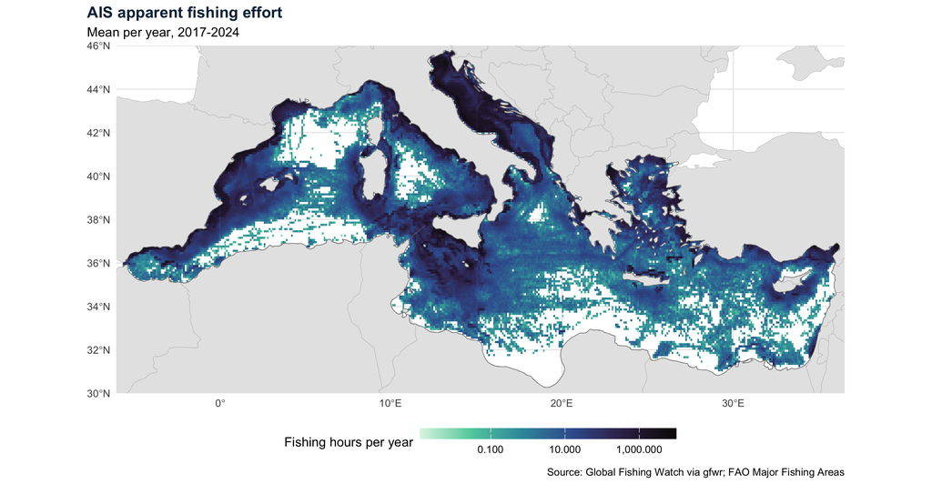

Figure 1: Mean annual AIS apparent fishing hours per 0.1° cell (log scale). Grey outline: FAO Area 37.1-37.3.

```r
ggplot(filter(ais_cell, hours > 0)) +
  tile(fill = hours) +
  scale_fill_viridis_c(trans = "log10", option = "mako", direction = -1,
                       labels = label_comma(), name = "Fishing hours per year") +
  map_base +
  labs(title = "AIS apparent fishing effort",
       subtitle = sprintf("Mean per year, %d-%d", min(yrs), max(yrs)),
       caption = "Source: Global Fishing Watch via gfwr; FAO Major Fishing Areas")
```

Fishing effort follows the continental shelf. The densest areas are the Adriatic, the Strait of Sicily and the Tunisian shelf down to the Gulf of Gabès, and the coasts of the Gulf of Lion, Catalonia and Liguria. The deep basins have patchy, low-intensity effort, and large parts of the Algerian and Libyan offshore waters record no AIS fishing at all.

## Seasonality and gear

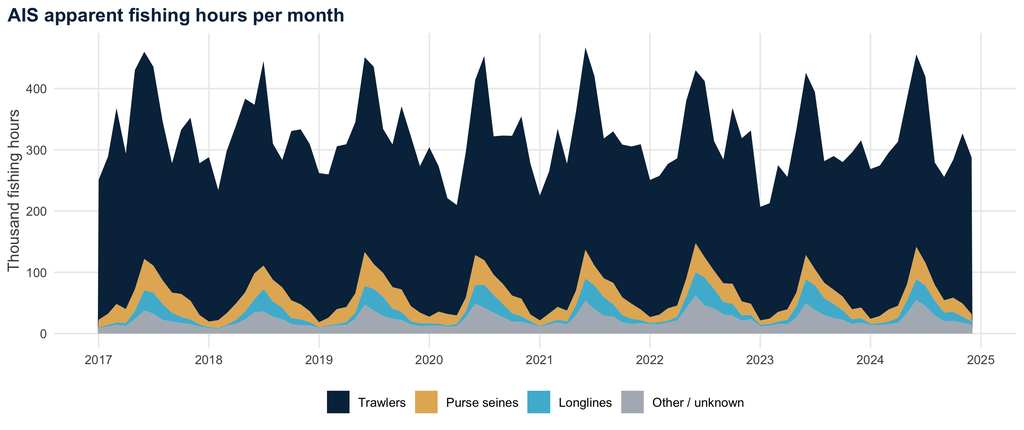

Figure 2: Monthly AIS apparent fishing hours by gear group.

```r
ais |>
  group_by(year, month, gear) |>
  summarise(hours = sum(fishing_hours), .groups = "drop") |>
  mutate(date = as.Date(sprintf("%d-%02d-01", year, month))) |>
  ggplot(aes(date, hours / 1e3, fill = gear)) +
  geom_area() +
  scale_fill_manual(values = c("Trawlers" = pal_ocean[["deep"]],
                               "Purse seines" = pal_ocean[["sand"]],
                               "Longlines" = pal_ocean[["light"]],
                               "Other / unknown" = pal_ocean[["grey"]])) +
  scale_x_date(date_breaks = "1 year", date_labels = "%Y") +
  labs(x = NULL, y = "Thousand fishing hours", fill = NULL,
       title = "AIS apparent fishing hours per month") +
  theme_ocean()
```

The series has a strong annual cycle. Averaged over the period, effort is lowest in January-February, peaks in June-July, then drops sharply in August. The August drop fits the summer trawl closures that several countries apply, such as Italy’s *fermo biologico*. Trawlers dominate year-round, and longlines and purse seines add a clear summer pulse. The unusually low March-April 2020 coincides with the first COVID-19 lockdowns.

## Vessels the radar sees but AIS does not

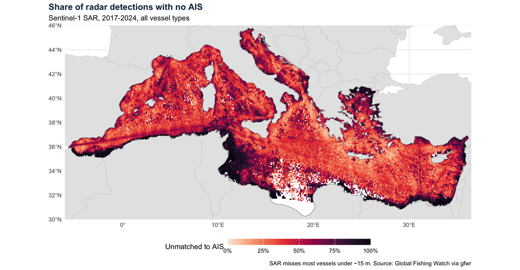

Figure 3: Share of SAR detections not matched to any AIS track, 2017-2024. Cells with at least 5 detections.

```r
ggplot(filter(sar_cell, det >= 5)) +
  tile(fill = dark_share) +
  scale_fill_viridis_c(option = "rocket", direction = -1, labels = label_percent(),
                       limits = c(0, 1), name = "Unmatched to AIS") +
  map_base +
  labs(title = "Share of radar detections with no AIS",
       subtitle = sprintf("Sentinel-1 SAR, %d-%d, all vessel types", min(yrs), max(yrs)),
       caption = "SAR misses most vessels under ~15 m. Source: Global Fishing Watch via gfwr")
```

### Correcting for satellite revisits

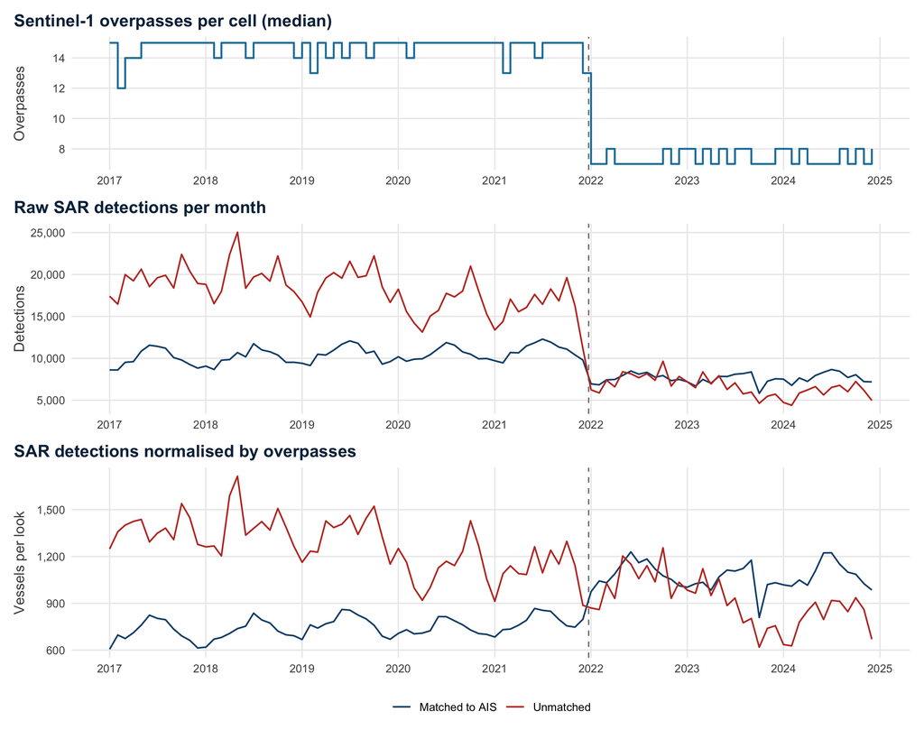

Figure 4: Top: median Sentinel-1 overpasses per cell and month. Middle: raw SAR detections. Bottom: vessels per look (detections ÷ overpasses, summed over cells). Dashed line: loss of Sentinel-1B (23 December 2021).

```r
s1b <- geom_vline(xintercept = as.Date("2021-12-23"), linetype = "dashed", colour = "grey50")
cols <- scale_colour_manual(values = c("Matched to AIS" = pal_ocean[["mid"]],
                                       "Unmatched" = pal_ocean[["alert"]]))
xax <- scale_x_date(date_breaks = "1 year", date_labels = "%Y")

p_ov <- ggplot(ov_month, aes(date, median_ov)) + s1b +
  geom_step(colour = pal_ocean[["surface"]], linewidth = 0.7) + xax +
  labs(x = NULL, y = "Overpasses", title = "Sentinel-1 overpasses per cell (median)") +
  theme_ocean()

p_raw <- sar |>
  group_by(year, month, matched) |>
  summarise(det = sum(detections), .groups = "drop") |>
  mutate(date = as.Date(sprintf("%d-%02d-01", year, month)),
         type = ifelse(matched, "Matched to AIS", "Unmatched")) |>
  ggplot(aes(date, det, colour = type)) + s1b +
  geom_line(linewidth = 0.6) + cols + xax +
  scale_y_continuous(labels = label_comma()) +
  labs(x = NULL, y = "Detections", colour = NULL, title = "Raw SAR detections per month") +
  theme_ocean() + theme(legend.position = "none")

p_norm <- snap_month |>
  pivot_longer(c(matched, unmatched), names_to = "type", values_to = "v") |>
  mutate(type = ifelse(type == "matched", "Matched to AIS", "Unmatched")) |>
  ggplot(aes(date, v, colour = type)) + s1b +
  geom_line(linewidth = 0.6) + cols + xax +
  scale_y_continuous(labels = label_comma()) +
  labs(x = NULL, y = "Vessels per look", colour = NULL,
       title = "SAR detections normalised by overpasses") +
  theme_ocean()

p_ov / p_raw / p_norm + plot_layout(heights = c(0.7, 1, 1))
```

The median cell was imaged about 15 times a month while both Sentinel-1A and 1B flew, and about 7 times a month afterwards. Raw detections fall by the same proportion, so most of the 2022 drop is a coverage effect. Once each cell’s detections are divided by its overpasses, the total number of vessels seen per look is stable across the break. It also shows a clean seasonal cycle, with more vessels at sea from May to October than in December-January.

The split between matched and unmatched detections is less stable. Matched vessels per look jump from 780 in 2021 to 1,094 in 2022, while unmatched vessels drop from 1,116 to 1,042. A step change that lines up exactly with the loss of a satellite is unlikely to be real behaviour. More plausibly, the AIS-matching step behaves differently with single-satellite coverage, or GFW’s processing changed at the same time. This is worth asking the GFW team about at the data lab. Within each coverage period the direction is consistent: unmatched vessels per look fell from 1,372 (2017) to 1,116 (2021), and from 1,042 (2022) to 811 (2024). Trends in “dark” activity should therefore be estimated within periods, or with a period term in the model.

## AIS effort and SAR by FAO division

**Summary by FAO division**

```r
div_tbl <- ais |>
  group_by(division) |>
  summarise(ais_h = sum(fishing_hours) / n_years,
            trawl = sum(fishing_hours[gear == "Trawlers"]) / sum(fishing_hours)) |>
  left_join(sar_cm |>
              group_by(division, year, month) |>
              summarise(m = sum(det_matched / overpasses),
                        u = sum(det_unmatched / overpasses), .groups = "drop") |>
              group_by(division) |>
              summarise(look = mean(m + u), dark = mean(u) / mean(m + u)),
            by = "division") |>
  left_join(cells |> count(division, name = "n_cells"), by = "division") |>
  mutate(ais_per_cell = ais_h / n_cells, look_100 = look / n_cells * 100) |>
  arrange(desc(ais_h))

div_tbl |>
  transmute(Division = division,
            `AIS fishing h / yr (k)` = fmt(ais_h / 1e3),
            `AIS h / cell / yr` = fmt(ais_per_cell),
            `Trawl share` = pct(trawl),
            `Vessels per look` = fmt(look),
            `Per 100 cells` = sprintf("%.1f", look_100),
            `Unmatched to AIS` = pct(dark)) |>
  kable(align = "lrrrrrr")
```

Table 2: Means over 2017-2024 by FAO division. Vessels per look: basin snapshot from SAR detections ÷ overpasses.

| Division | AIS fishing h / yr (k) | AIS h / cell / yr | Trawl share | Vessels per look | Per 100 cells | Unmatched to AIS |
| --- | --- | --- | --- | --- | --- | --- |
| Adriatic | 1,085 | 895 | 84% | 132 | 10.9 | 54% |
| Balearic | 779 | 157 | 76% | 394 | 8.0 | 54% |
| Ionian | 753 | 92 | 81% | 509 | 6.2 | 57% |
| Sardinia | 639 | 184 | 84% | 244 | 7.0 | 52% |
| Aegean | 388 | 124 | 78% | 319 | 10.2 | 58% |
| Levant | 136 | 31 | 66% | 367 | 8.4 | 63% |
| Gulf of Lions | 101 | 140 | 86% | 41 | 5.7 | 46% |

## How well does AIS effort track radar-detected vessels?

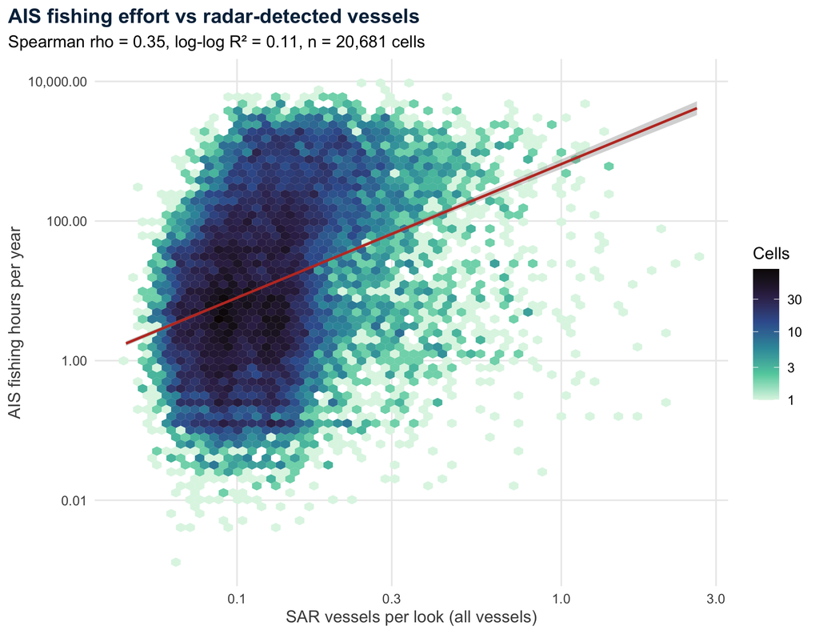

Figure 5: AIS fishing hours per year vs SAR vessels per look, per 0.1° cell (log scales). Red line: log-log linear fit.

```r
both <- filter(cell, hours > 0, det > 0)
rho  <- cor(both$hours, both$per_look, method = "spearman")
fit  <- lm(log10(hours) ~ log10(per_look), data = both)

ggplot(both, aes(per_look, hours)) +
  geom_hex(bins = 60) +
  geom_smooth(method = "lm", formula = y ~ x, colour = pal_ocean[["alert"]], linewidth = 0.8) +
  scale_x_log10(labels = label_comma()) +
  scale_y_log10(labels = label_comma()) +
  scale_fill_viridis_c(option = "mako", direction = -1, trans = "log10", name = "Cells") +
  labs(x = "SAR vessels per look (all vessels)", y = "AIS fishing hours per year",
       title = "AIS fishing effort vs radar-detected vessels",
       subtitle = sprintf("Spearman rho = %.2f, log-log R² = %.2f, n = %s cells",
                          rho, summary(fit)$r.squared, fmt(nrow(both)))) +
  theme_ocean() + theme(legend.position = "right")
```

**Cells seen by one source only**

```r
coverage <- cell |>
  summarise(both = sum(det > 0 & hours > 0),
            sar_only = sum(det > 0 & hours == 0),
            ais_only = sum(det == 0 & hours > 0),
            sar_in_sar_only = sum(det[hours == 0]) / sum(det))
```

In the 20,681 cells where both sources record activity, they are only weakly related (Spearman ρ = 0.35). SAR vessels per look explain only about 11% of the variation in log AIS effort. Another 5,350 cells have radar detections but no AIS fishing at all, and they hold 13% of all SAR detections. Many of these are shipping lanes and ports, but some will be fishing by vessels without AIS. Only 76 cells have AIS fishing but no radar detection at all: across eight years of revisits, almost everywhere AIS records fishing, the radar sees vessels too.

There are two reasons for the weak relationship. Radar counts every vessel present at the moment the satellite passes, while AIS effort sums hours of fishing behaviour over the whole month. And each source misses a different part of the fleet. Environmental and seabed covariates are what should help explain the difference.

## Caveats

- **SAR counts all vessels.** These detections are not filtered to fishing vessels. A next step is to apply GFW’s fishing classification of SAR detections (`neural_vessel_type`) or to mask shipping lanes.
- **Overpasses are an approximation of what GFW processed.** They count every catalogued Sentinel-1 IW GRD pass over a cell centre. GFW’s own processing may skip some scenes, and detection near the edge of a swath can be weaker.
- **Small-scale fisheries are largely invisible.** Most of the Mediterranean fleet is under 12 m and neither carries AIS nor shows up reliably in SAR.
- **AIS fishing hours are modelled.** “Apparent fishing” is a classification of vessel movement, and gear labels come from GFW’s vessel identity models (`fishing` and `inconclusive` are grouped here as Other / unknown).
- **Coastal cells.** Cells are kept if their square touches FAO Area 37.1-37.3, so coastal cells partly on land are included.

## Next steps for the data lab

1. **Predicting fishing effort.** Add environmental and climate covariates from Copernicus Marine reanalysis (temperature, mixed-layer depth, chlorophyll, primary production), plus depth, distance to port and distance to coast. Then model AIS effort, and the SAR-AIS gap, at the cell-month level, using vessels per look as the SAR response.
2. **Fishing and MPAs.** Overlay WDPA marine protected areas with their designation dates and protection levels. Then test whether effort changes after designation, how it varies across MPA boundaries, and whether MPAs were placed in already low-effort areas.